# Lesson 3

### What to Do First?

EDA means learn about surprises in the data. Features of data that may lead to unexpected results. Often, this is going to the format of producing summaries and visualizations of those individual variables. ***

### Pseudo-Facebook User Data

Notes:

```r
getwd()
```

```
## [1] "F:/learn_data/R/Data-Analysis-with-R_udacity/lesson3"
```

```r
list.files()
```

```
## [1] "lesson3_student.rmd" "pseudo_facebook.tsv"
```

```r
pf<-read.csv('pseudo_facebook.tsv',sep='\t')
dim(pf)
```

```
## [1] 99003    15
```

```r
names(pf)
```

```
##  [1] "userid"                "age"
##  [3] "dob_day"               "dob_year"
##  [5] "dob_month"             "gender"
##  [7] "tenure"                "friend_count"
##  [9] "friendships_initiated" "likes"
## [11] "likes_received"        "mobile_likes"
## [13] "mobile_likes_received" "www_likes"
## [15] "www_likes_received"
```

[themes](https://github.com/jrnold/ggthemes#examples) When you register at a websites, some sites have default setting that use the 1st day of the month under the birth day field. Some also use a default month of January. In the case of Facebook, Jan and the 1st are the first drop down items that appear on the site. It’s important to think about such details and the data generating process when exploring data. ### Histogram of Users’ Birthdays

```r
library(ggplot2)
names(pf)
```

```
##  [1] "userid"                "age"
##  [3] "dob_day"               "dob_year"
##  [5] "dob_month"             "gender"
##  [7] "tenure"                "friend_count"
##  [9] "friendships_initiated" "likes"
## [11] "likes_received"        "mobile_likes"
## [13] "mobile_likes_received" "www_likes"
## [15] "www_likes_received"
```

```r
summary(pf$dob_day)
```

```
##    Min. 1st Qu.  Median    Mean 3rd Qu.    Max.
##    1.00    7.00   14.00   14.53   22.00   31.00
```

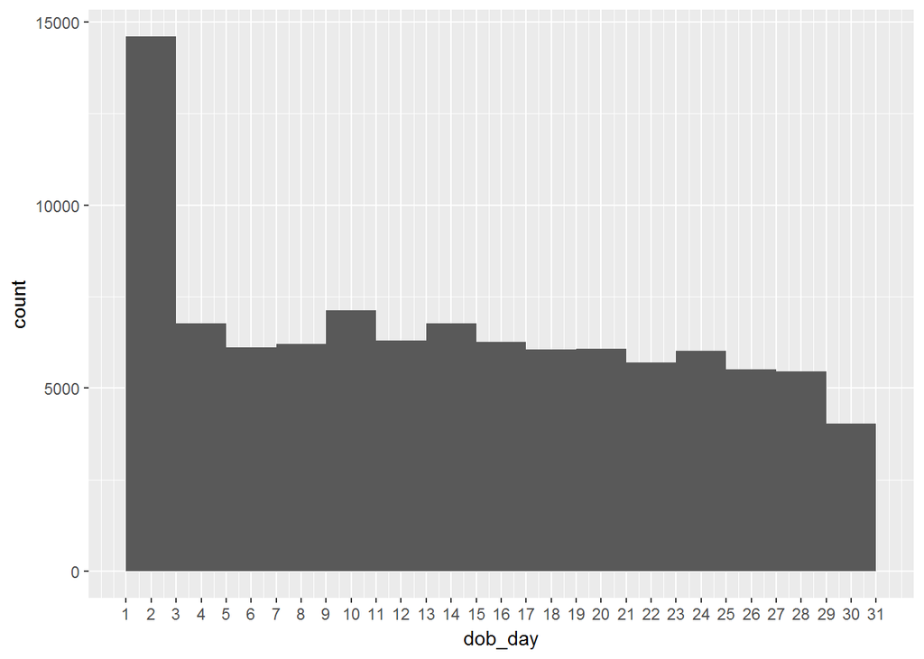

```r
qplot(x=dob_day,data=pf,binwidth=2)+
  scale_x_continuous(breaks=1:31)
```

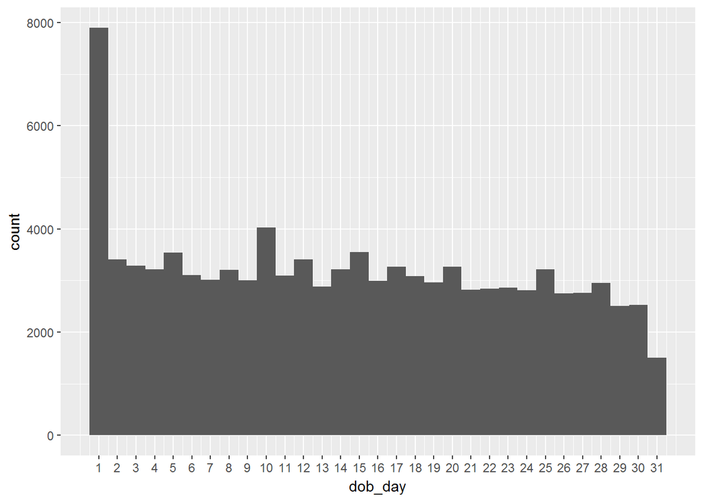

```r
ggplot(aes(x = dob_day), data = pf) +
  geom_histogram(binwidth = 1) +
  scale_x_continuous(breaks = 1:31)
```

### Faceting

- (facet)[http://www.cookbook-r.com/Graphs/Facets_(ggplot2)/]
1. facet_wrap(~variable) This helps you to create the same type of plot for each level of your categorical variable. In our case, we wanna make histograms of dob day, one for each month of the year.
2. facet_grid(vertical~horizontal) Variables that we wanna split over in the vertical and horizontal direction

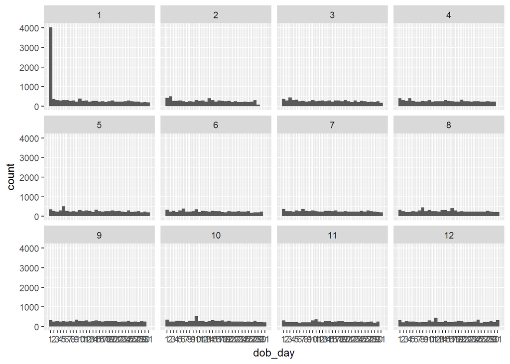

```r
qplot(x=dob_day,data=pf,binwidth=1)+
  scale_x_continuous(breaks=1:31)+
  facet_wrap(~dob_month,ncol=4)
```

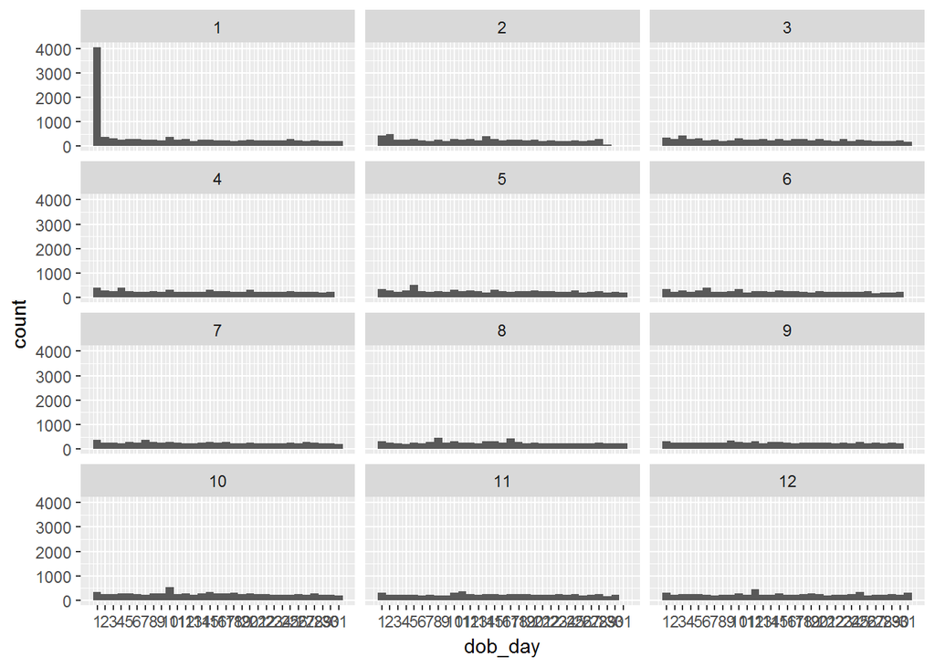

```r
ggplot(aes(x = dob_day), data = pf) +
  geom_histogram(binwidth = 1) +
  scale_x_continuous(breaks = 1:31)+
  facet_wrap(~dob_month,ncol=3)
```

### Be Skeptical - Outliers and Anomalies Outliers have many types

1. accurate data about an extreme case
2. bad or limitations of your data  
   +a normal value be replaced by an extreme value  
   +an extreme value be replaced by a normal value([top-coded](https://en.wikipedia.org/wiki/Top-coded))

#### What code would you enter to create a histogram of friend counts?

##### long tail data

This data can be common for some user level data.  
Most people have friend_counts under 500.  
While we may want to investigate some observations in this tail, we really want to examine users with friend counts well below 1000.

```r
str(pf)
```

```
## 'data.frame':    99003 obs. of  15 variables:
##  $ userid               : int  2094382 1192601 2083884 1203168 1733186 1524765 1136133 1680361 1365174 1712567 ...
##  $ age                  : int  14 14 14 14 14 14 13 13 13 13 ...
##  $ dob_day              : int  19 2 16 25 4 1 14 4 1 2 ...
##  $ dob_year             : int  1999 1999 1999 1999 1999 1999 2000 2000 2000 2000 ...
##  $ dob_month            : int  11 11 11 12 12 12 1 1 1 2 ...
##  $ gender               : Factor w/ 2 levels "female","male": 2 1 2 1 2 2 2 1 2 2 ...
##  $ tenure               : int  266 6 13 93 82 15 12 0 81 171 ...
##  $ friend_count         : int  0 0 0 0 0 0 0 0 0 0 ...
##  $ friendships_initiated: int  0 0 0 0 0 0 0 0 0 0 ...
##  $ likes                : int  0 0 0 0 0 0 0 0 0 0 ...
##  $ likes_received       : int  0 0 0 0 0 0 0 0 0 0 ...
##  $ mobile_likes         : int  0 0 0 0 0 0 0 0 0 0 ...
##  $ mobile_likes_received: int  0 0 0 0 0 0 0 0 0 0 ...
##  $ www_likes            : int  0 0 0 0 0 0 0 0 0 0 ...
##  $ www_likes_received   : int  0 0 0 0 0 0 0 0 0 0 ...
```

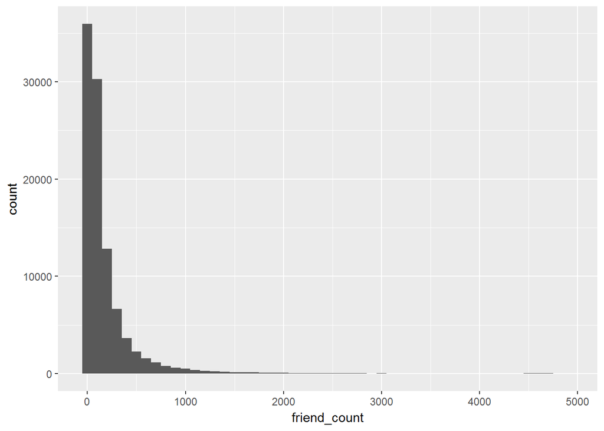

```r
ggplot(aes(x=friend_count),data=pf)+
  geom_histogram(binwidth=100)
```

### Limiting the Axes (scale_continuous)[http://docs.ggplot2.org/current/scale_continuous.html]

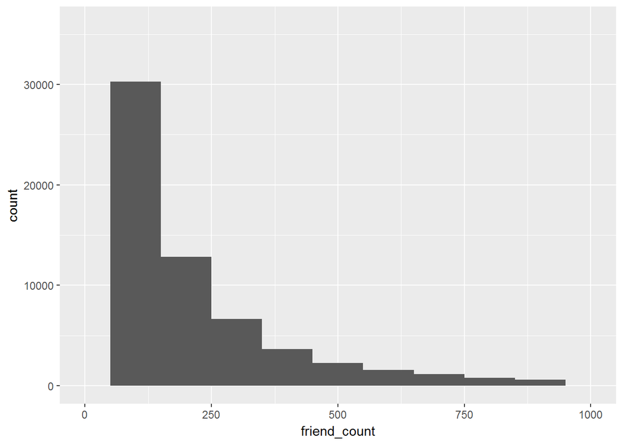

```r
ggplot(aes(x=friend_count),data=pf)+
  geom_histogram(binwidth=100)+
  scale_x_continuous(limits=c(0,1000))
```

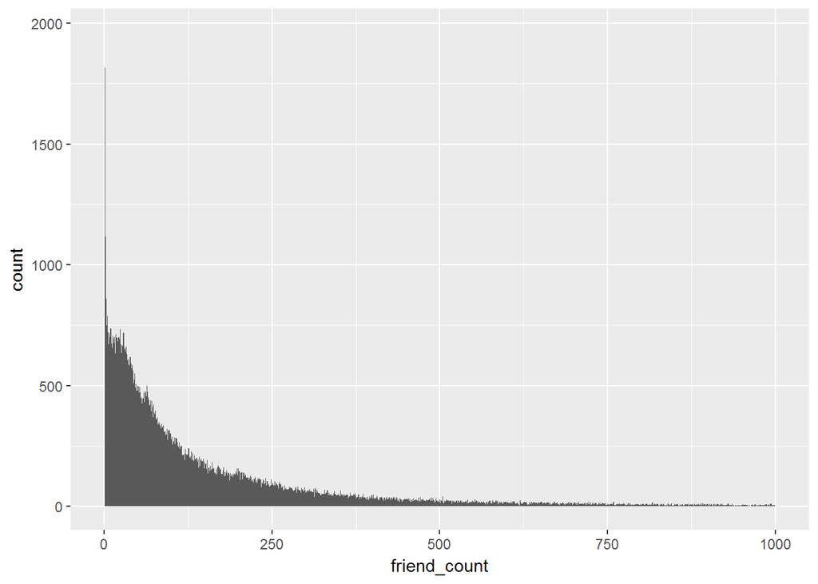

```r
qplot(x=friend_count,data=pf,binwidth=1,xlim=c(0,1000))
```

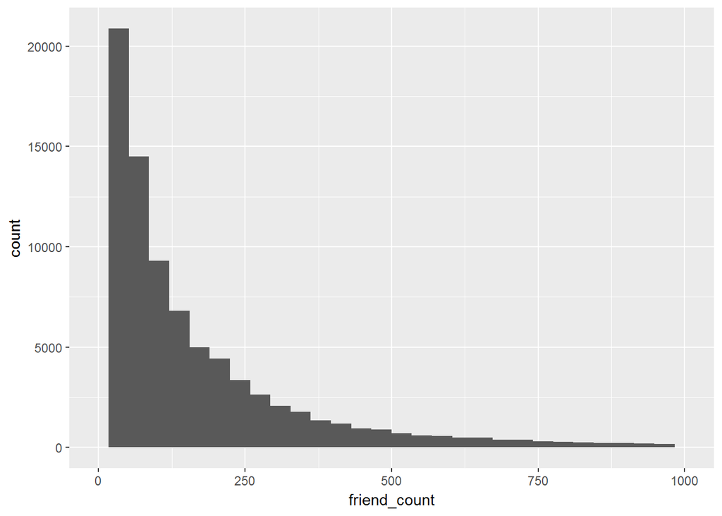

```r
qplot(x=friend_count,data=pf)+
  scale_x_continuous(limits=c(0,1000))
```

### Faceting Friend Count

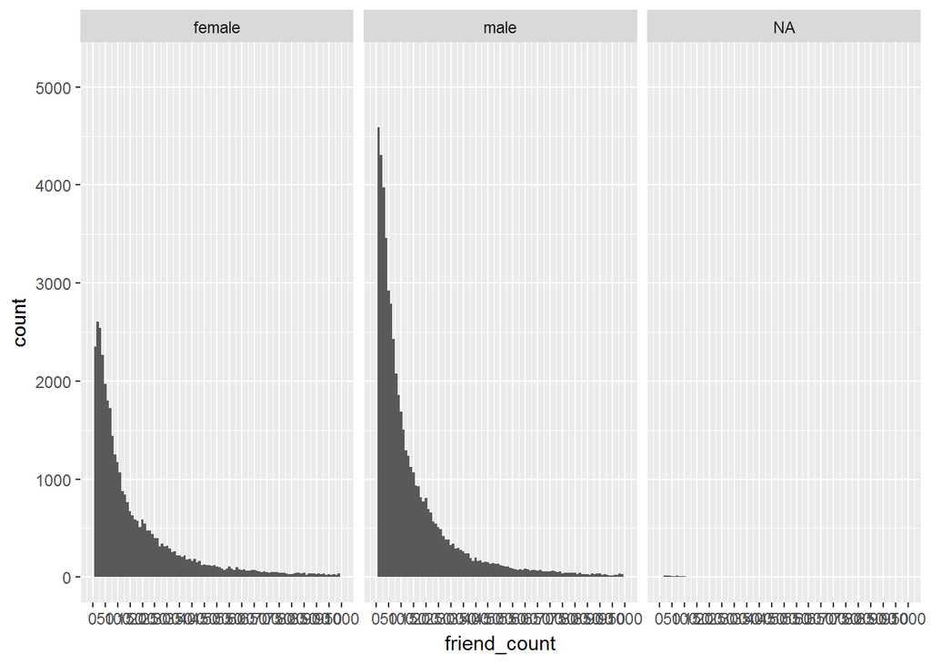

```r
# What code would you add to create a facet the histogram by gender?
# Add it to the code below.
qplot(x = friend_count, data = pf, binwidth = 10) +
  scale_x_continuous(limits = c(0, 1000),breaks = seq(0, 1000, 50))+
  facet_wrap(~gender)
```

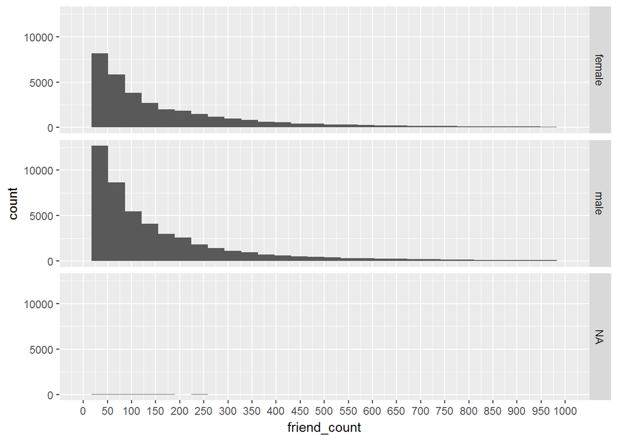

```r
ggplot(aes(x = friend_count), data = pf) +
  geom_histogram() +
  scale_x_continuous(limits = c(0, 1000), breaks = seq(0, 1000, 50)) +
  facet_grid(gender~.)
```

### Omitting NA Values

missing values take on the value of NA

```r
dim(pf)
```

```
## [1] 99003    15
```

```r
dim(na.omit(pf))
```

```
## [1] 98826    15
```

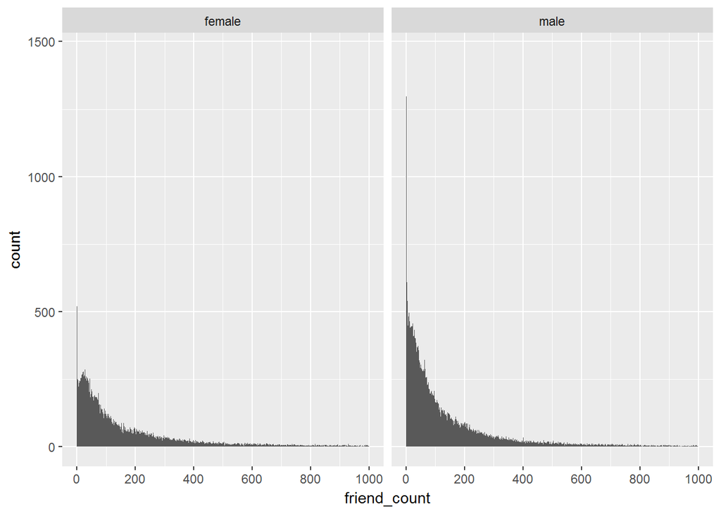

```r
ggplot(aes(x = friend_count), data = subset(pf, !is.na(gender))) +
  geom_histogram(binwidth = 1) +
  scale_x_continuous(limits = c(0, 1000), breaks = seq(0, 1000, 200)) +
  facet_wrap(~gender)
```

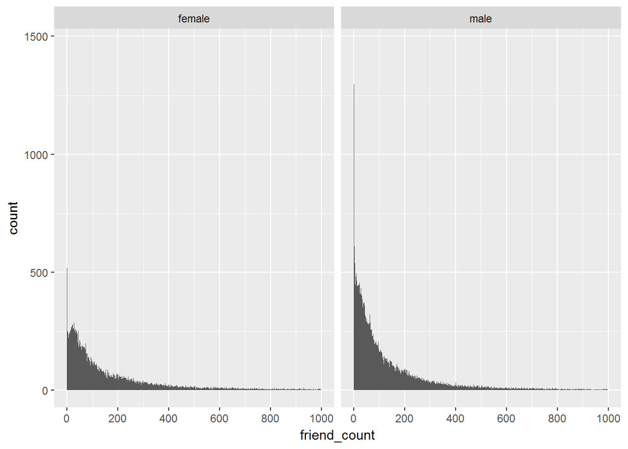

```r
##remove any observations that have na in them, not necessarily just for gender variable
ggplot(aes(x = friend_count), data = na.omit((pf))) +
  geom_histogram(binwidth = 1) +
  scale_x_continuous(limits = c(0, 1000), breaks = seq(0, 1000, 200)) +
  facet_wrap(~gender)
```

### Statistics ‘by’ Gender

Considering the plots above, it’s hard to determine which gender has more friend on average. Who has more friends, male or females.

To look at the average friend count by gender, we need *by* command

```r
table(pf$gender)
```

```
##
## female   male
##  40254  58574
```

```r
#1 a variable
#2 a categorical variable, or the variable that contains our segment of users
#3 a function--wanna a summary of the friend count by gender
by(pf$friend_count,pf$gender,summary)
```

```
## pf$gender: female
##    Min. 1st Qu.  Median    Mean 3rd Qu.    Max.
##       0      37      96     242     244    4923
## --------------------------------------------------------
## pf$gender: male
##    Min. 1st Qu.  Median    Mean 3rd Qu.    Max.
##       0      27      74     165     182    4917
```

#### What’s the difference between the median friend count for women and men?

Response: Mean for friend count is higher than median. This should make sense since our data is long-tailed. The higher values of frient_count will pull our mean to the right.

In this case, the meadian is a more robust statistic. A few people drag the mean upwards which isn’t necessarily representative of most users. What’s nice is the median is resistant to change, so it’s a reliable location of the center.

### Tenure

+(continuous position scales)[http://docs.ggplot2.org/current/scale_continuous.html] +(theme set)[http://docs.ggplot2.org/0.9.2.1/theme.html] + The parameter color determines the color outline of objects in a plot. + The parameter fill determines the color of the area inside objects in a plot.

You might notice how the color black and the (hex code)[https://en.wikipedia.org/wiki/Web_colors] color of #099DD9 (a shade of blue) are wrapped inside of I().

- The I() functions stand for ‘as is’ and tells qplot to use them as colors.

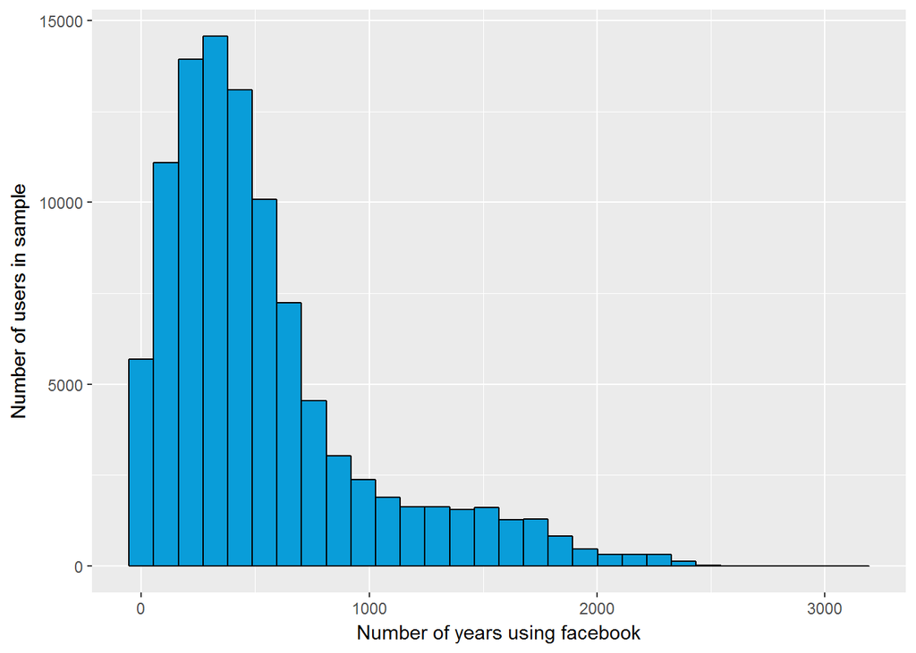

```r
qplot(x=tenure,data=pf,
      color=I('black'),fill=I('#099DD9'),
      xlab='Number of years using facebook',
      ylab='Number of users in sample')
```

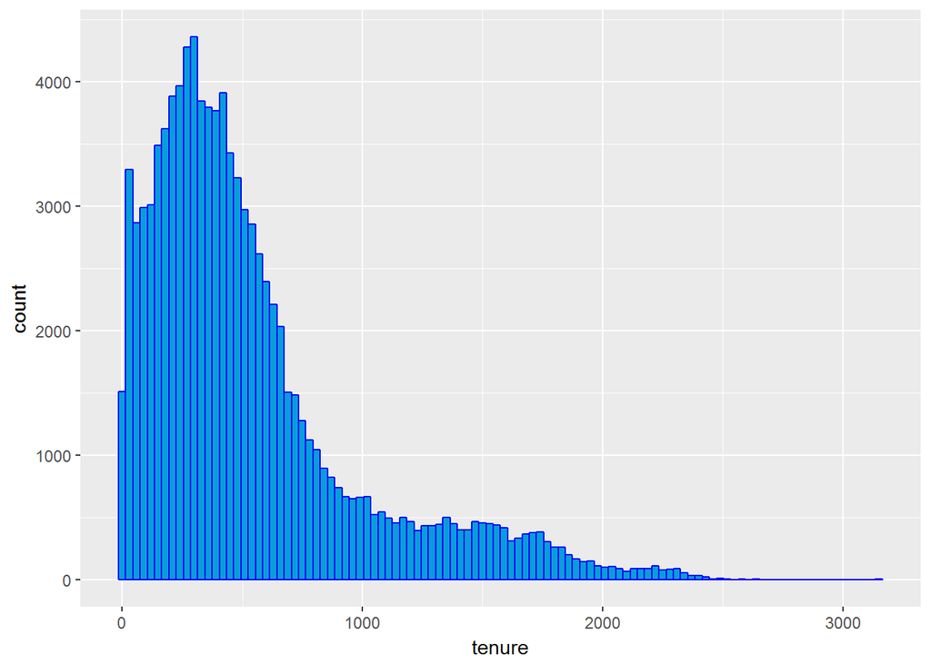

```r
#histogram of tenure measured by days
#30 days is a month, so make the binwidth=30
ggplot(aes(x=tenure),data=pf)+
  geom_histogram(binwidth=30,color='blue', fill = '#099DD9')
```

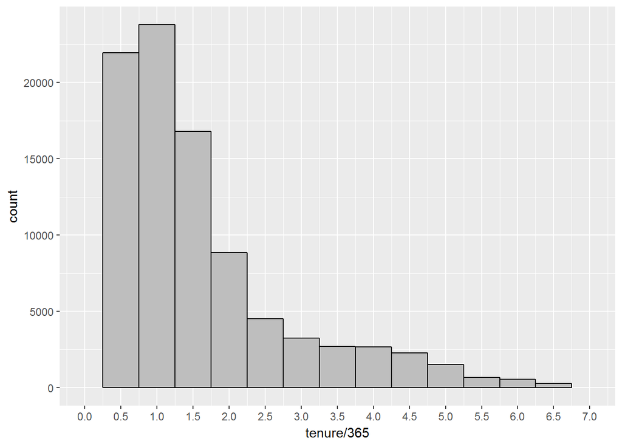

```r
#histogram of tenure measured by years
#limit our data, so that we can only see data from one to seven years
ggplot(aes(x = tenure/365), data = pf) +
   geom_histogram(binwidth = .5, color = 'black', fill = 'grey')+
  scale_x_continuous(breaks=(seq(0,8,0.5)),limits=c(0,7))
```

### Labeling Plots

When you conduct EDA, your plots don’t need to be perfect. Do focus on choices for scales and limits on each axis. Labels can function as comments about what the code intended to do.

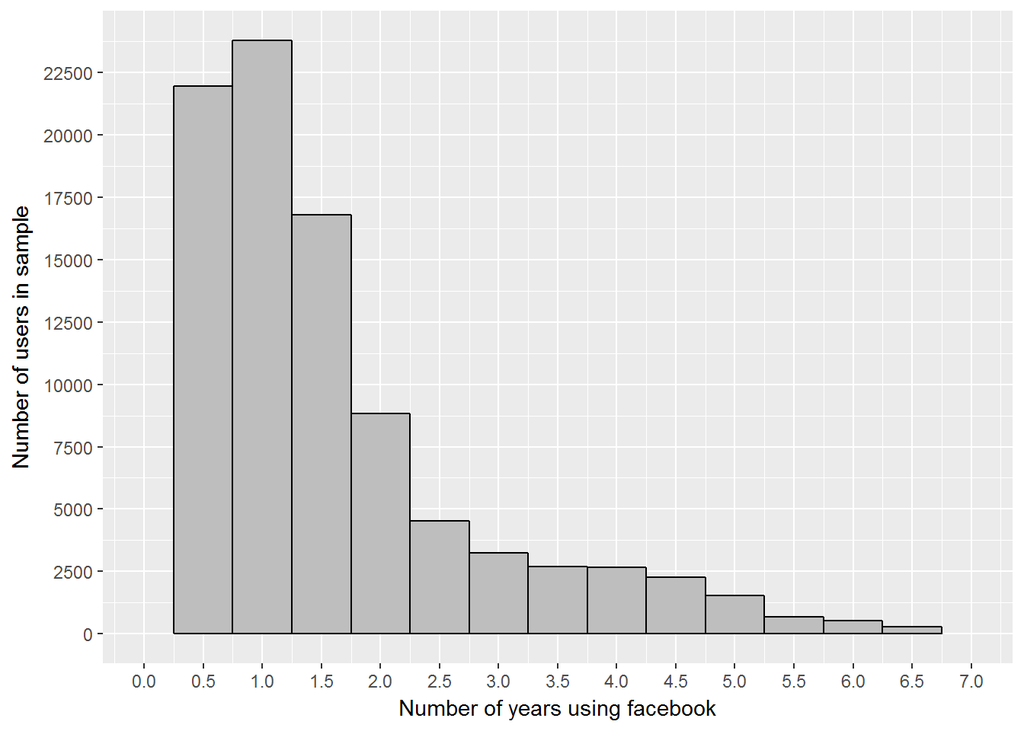

```r
ggplot(aes(x = tenure/365), data = pf) +
  xlab('Number of years using facebook')+
  ylab('Number of users in sample')+
  geom_histogram(binwidth = .5, color = 'black', fill = 'grey')+
  scale_x_continuous(breaks=(seq(0,8,0.5)),limits=c(0,7))+
  scale_y_continuous(breaks=(seq(0,30000,2500)))
```

### User Ages

Notes:

```r
summary(pf$age)
```

```
##    Min. 1st Qu.  Median    Mean 3rd Qu.    Max.
##   13.00   20.00   28.00   37.28   50.00  113.00
```

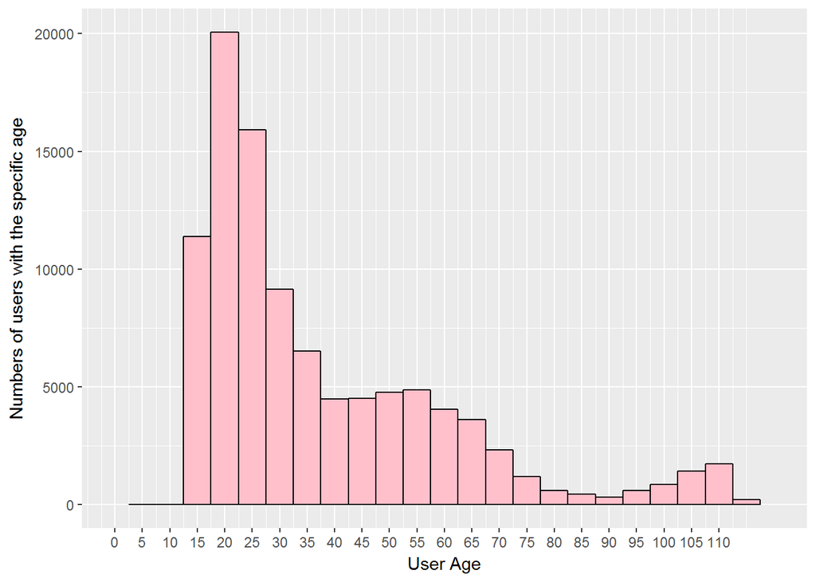

```r
ggplot(aes(x=age),data=subset(pf,!is.na(age)))+
  geom_histogram(binwidth = 5,color='black',fill='pink')+
  scale_x_continuous(breaks=seq(0,113,5),limits=c(0,120))+
  scale_y_continuous(breaks=seq(0,60000,5000))+
  xlab('User Age')+
  ylab('Numbers of users with the specific age')
```

### Transforming Data + Most of our variables, such as friend_coumnt, likes are variables that I would call *engagement variables*, and they all have very long tails. Some users have 10 times, or even 100, the median value.  
In statistics, we say that the data is *over dispersed*. Often, we will transform these values so we can see standard deviations, or orders of magnitudes so as to shortening the tail. “Over-dispersed” is always relative to some particular posited distribution. For example, data might be over-dispersed compared with a Poisson distribution with that mean. + We can transform these variables by *taking the log*, either using the natural log, the log base 2 or log base 10. We can also use square root to help us see patterns more clearly, without being distracted by long tails. + A lot of statistical techniques like linear regression are based on assumption that variables have normal distributions. So by taking the log of variable, we can transform our data into something resembles a normal distribution. +(normal distribution)[https://en.wikipedia.org/wiki/Normal_distribution] +(multiple plots in one graph using gridExtra)[http://lightonphiri.org/blog/ggplot2-multiple-plots-in-one-graph-using-gridextra] +(Log Transformations for Skewed and Wide Distributions)[https://www.r-statistics.com/2013/05/log-transformations-for-skewed-and-wide-distributions-from-practical-data-science-with-r/] +(scale continuous)[http://docs.ggplot2.org/current/scale_continuous.html]

```r
summary(pf$friend_count)
```

```
##    Min. 1st Qu.  Median    Mean 3rd Qu.    Max.
##     0.0    31.0    82.0   196.4   206.0  4923.0
```

```r
summary(log10(pf$friend_count+1))
```

```
##    Min. 1st Qu.  Median    Mean 3rd Qu.    Max.
##   0.000   1.505   1.919   1.868   2.316   3.692
```

```r
summary(sqrt(pf$friend_count))
```

```
##    Min. 1st Qu.  Median    Mean 3rd Qu.    Max.
##   0.000   5.568   9.055  11.090  14.350  70.160
```

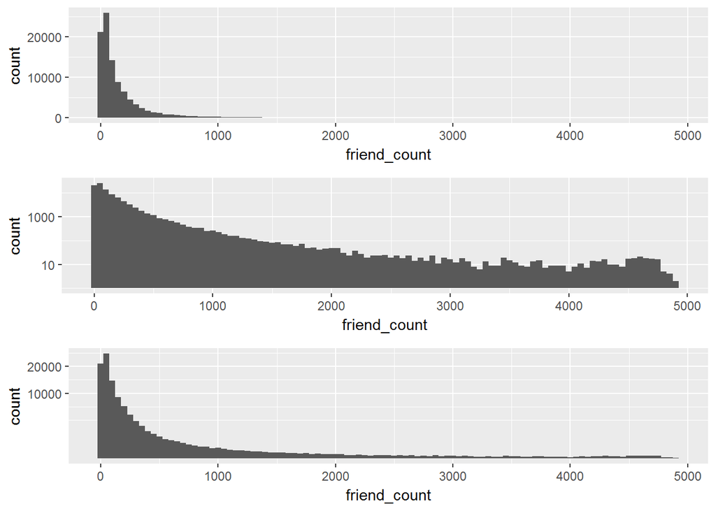

```r
#   Install gridExtra
#install.packages("gridExtra")
library(gridExtra)
#define individual plots
p1=ggplot(aes(friend_count),data=subset(pf,!is.na(friend_count)))+
  geom_histogram(binwidth=50)

p2=ggplot(aes(friend_count),data=subset(pf,!is.na(friend_count)))+
  geom_histogram(binwidth=50)+
  scale_y_log10()

p3=ggplot(aes(friend_count),data=subset(pf,!is.na(friend_count)))+
  geom_histogram(binwidth=50)+
  scale_y_sqrt()
#arrange plots in grid
grid.arrange(p1,p2,p3,ncol=1)
```

### Add a Scaling Layer

Notes:

### Likes on the Web

Notes:

### Box Plots

Notes:

#### Adjust the code to focus on users who have friend counts between 0 and 1000.

### Box Plots, Quartiles, and Friendships

Notes:

#### On average, who initiated more friendships in our sample: men or women?

Response: #### Write about some ways that you can verify your answer. Response:

Response:

### Getting Logical

Notes:

Response:

### Analyzing One Variable

Reflection:

Click **KnitHTML** to see all of your hard work and to have an html page of this lesson, your answers, and your notes!